# ¿Cuál es tu barrio ideal en la Ciudad Autónoma de Buenos Aires?

Trabajo final grupal para el curso de Data Analytics con R de la Escuela Argentina de Nuevas Tecnologías (EANT)

Rafael Carvajal, Alejandro Pocoroba y Yamila Sasal

2021-07-23

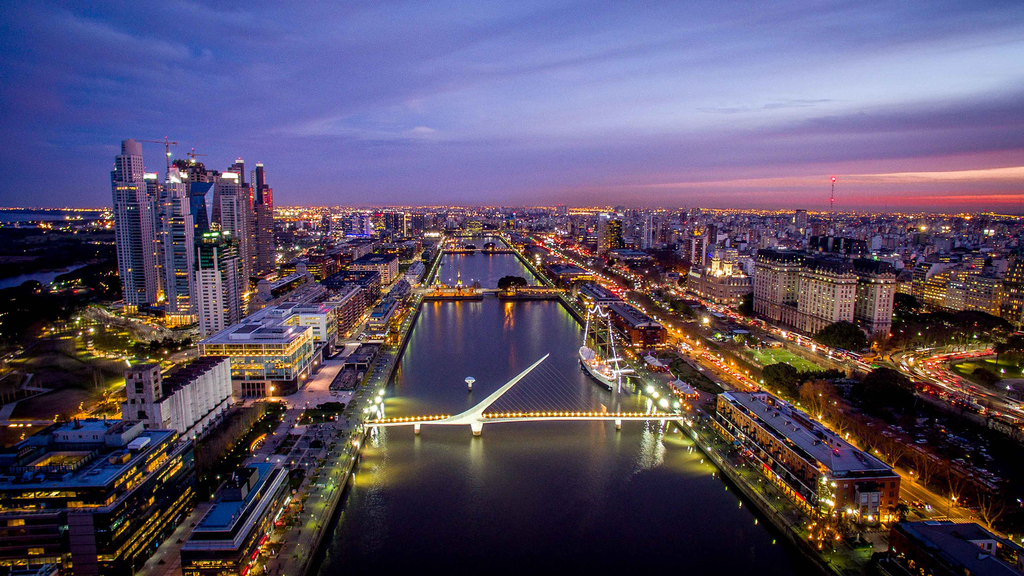

# Introducción

El objetivo del trabajo fue explorar ¿Cuál es tu barrio ideal en la Ciudad Autónoma de Buenos Aires (CABA, Argentina)? Al elegir en donde vivir, cada persona tiene distintas preferencias en cuanto a que es imprescindible y debe tener el lugar ideal. Definimos 6 criterios que consideramos podrían definir la búsqueda del barrio ideal, estos son:

1. disponibilidad de escuelas,
2. espacios deportivos,
3. precio de alquileres,
4. familiar (con niños y adolescentes),
5. centros de salud, y
6. transporte.

Los datos los obtuvimos de Buenos Aires Data, posteriormente construimos una variable numérica que cuantificó dichos criterios para cada comuna (15 comunas a las que pertenecen los 48 barrios). Luego cada comuna adquirió una ponderación entre 1 y 5, donde 1 es menos preferido y 5 es la mayor preferencia. Finalmente eligiendo 4 criterios, el primero que se elige siempre tendrá más valor sobre los otros, obtenemos la comuna y los posibles barrios ideales para vivir.

Si tenés planes de mudarte próximamente a CABA, este análisis te ayudará a descubrir cuál es tu barrio ideal para vivir.

# Bases de datos

Los datos utilizados fueron obtenidos del portal de datos abiertos de la Ciudad Autónoma de Buenos Aires: Buenos Aires Data https://data.buenosaires.gob.ar/ . Las bases usadas para cada criterio fueron:

- Comunas CABA: Comunas y barrios de CABA
- Escuelas: Establecimientos educativos
- Familiar: Rango de edad de la población entre 5 y 19 años
- Población por edad y comuna 2021
- Espacios deportivos: Clubes de Barrio, Polideportivos y Espacios verdes públicos
- Centros de salud: Hospitales, Centros de salud (CESAC), Estaciones saludables y Centros de salud privados
- Transporte: Estaciones de bicicletas, Estaciones de ferrocarriles y Estaciones de Metrobus

A continuación presentamos los análisis que realizamos, junto con el código correspondiente. Antes de empezar importamos las librerías necesarias.

```r
# Librerías necesarias
require(pacman) # instala e invoca varias librerias
p_load(readxl, tidyverse, dplyr, sf, viridis, janitor, ggmap,leaflet, ggplot2, reshape2, hrbrthemes, DT, kableExtra, forcats)
options(dplyr.summarise.inform = FALSE) # Para que no tire error en group_by
```

# 1. Criterio escuelas

Consideramos que el barrio ideal para mucha gente debe tener escuelas de distintos niveles: inicial, primarias y secundarias. ¿Cuáles son los barrios con más escuelas disponibles? Para responder a esta pregunta seleccionamos sólo jardines de infantes, escuelas primarias y secundarias, y filtramos los establecimientos para jóvenes y adultos.

```r
# Establecimientos educativos. Fuente: BA Data.
escuelas <- st_read('https://cdn.buenosaires.gob.ar/datosabiertos/datasets/ministerio-de-educacion/establecimientos-educativos/establecimientos_educativos_WGS84.geojson')

# Ordenamos y seleccionamos los datos
escuelas <- escuelas %>%
  select(cui, cue, nombre_est, nivmod, nivelmodal, depfun, de, comuna, barrio, point_x, point_y,geometry)
```

```r
# Vemos que hay muchos tipos de establecimientos educativos
length(unique(escuelas$nivelmodal))
tabla <- table(escuelas$nivelmodal)

# Filtramos los establecimientos para jovenes y adultos, nos quedamos solo con los establecimientos comunes y especiales de tipo jardin de infantes, escuelas primarias y secundarias.
jov_adultos_y_otros <- c("Nivel Primario de Jóvenes y Adultos", "Nivel Primario de Jóvenes y Adultos - Otros Servicios Educativos de la modalidad de Jóvenes y Adultos", "Nivel Primario y Secundario de Jóvenes y Adultos", "Nivel Secundario de Jóvenes y Adultos", "Nivel Secundario de Jóvenes y Adultos y Nivel Superior No Universitario Común", "Nivel Secundariode Jóvenes y Adutos y Otros Servicios Educativos de la modalidad de Jóvenes y Adultos - Nivel Superior No Universitario Común", "Nivel Superior No Universitario Común", "Nivel Superior No Universitario Común - Otros Servicios Educativos de la modalidad de Jóvenes y Adultos", "Nivel Superior No Universitario Común y Otros Servicios Educativos de la modalidad Común", "Otros Servicios Educativos de la modalidad Común", "Otros Servicios Educativos de la modalidad de Jóvenes y Adultos", "Otros Servicios Educativos de la modalidad Especial", "Otros Servicios Educativos de las modalidades Común y de Jóvenes y Adultos")

escuelas_chicos <- escuelas %>%
   filter(!nivelmodal %in% jov_adultos_y_otros) %>%
   group_by(nivelmodal) %>%
   arrange(comuna,barrio)
```

```r
# Contamos el número de establecimientos educativos para niños y adolecentes por comuna.
escuelas_chicos_comuna <- escuelas_chicos %>%
  group_by(comuna) %>%
  count(name="escuelas_chicos") %>%
  arrange(desc(escuelas_chicos))

escuelas_chicos_comuna
```

Sin embargo, la disponibilidad de vacantes dependerá de la cantidad de niños y niñas que asistan a eso espacios educativos. Buscamos la poblacion de cada comuna agrupada por rango de edades y seleccionamos las edades entre 5 y 19 años.

```r
# Población en edad escolar por comuna. Fuente: BA Data.
# Población según comuna y edad, es una hoja de un excel por año que descargue a mi computadora.

Poblacion_por_comuna_y_edad <- read.csv("poblacion_edad_comuna_2021.csv")

Pobl_edad_escolar <- Poblacion_por_comuna_y_edad %>%
  tidyr::pivot_longer(cols = -"Grupo_de_edad",
                       names_to = "comunas",
                       values_to = "poblacion")


# me quedo con los grupos de 5-9, 10-14 y 15-19 años
chicos_edad_escolar <- Pobl_edad_escolar %>%
   filter(Grupo_de_edad %in% c("5-9","10-14","15-19")) %>%
   group_by(comunas) %>%
   summarise(chicos_comunas=sum(poblacion)) %>%
  arrange(desc(chicos_comunas))

chicos_edad_escolar
```

Encontramos que la comuna con mas niños y adolescentes es la 8 con casi 65000 y la comuna con menos es la 2 con alrededor de 21800.

Por lo tanto, para conocer la disponibilidad de escuelas relacionamos el número de escuelas por comuna con la población de niños y niñas, luego calculamos el número de estudiantes por unidad educativa. Es decir, niños y niñas entre escuelas.

```r
chicos_edad_escolar <-  chicos_edad_escolar %>%
   tidyr::separate(col = comunas,into=c("comunas_ch", "comunas_n"),sep = "_") %>%
   mutate(comunas_n=as.numeric(comunas_n)) %>%
  mutate(comunas_ch=NULL)

escuelas_comuna <- chicos_edad_escolar %>%
   left_join(escuelas_chicos_comuna,by=c("comunas_n"="comuna")) %>%
    mutate(alumn_p_escuelas=chicos_comunas/escuelas_chicos) %>%
    select (-geometry) %>%
arrange(desc(alumn_p_escuelas))

escuelas_comuna <- escuelas_comuna %>%
  mutate(comunas_n=as.factor(comunas_n)) %>%
  mutate(comunas=as.numeric(comunas_n))
```

El criterio 1, medido como la relacion número de alumnos por escuela, que nos indica la disponibilidad de escuelas.

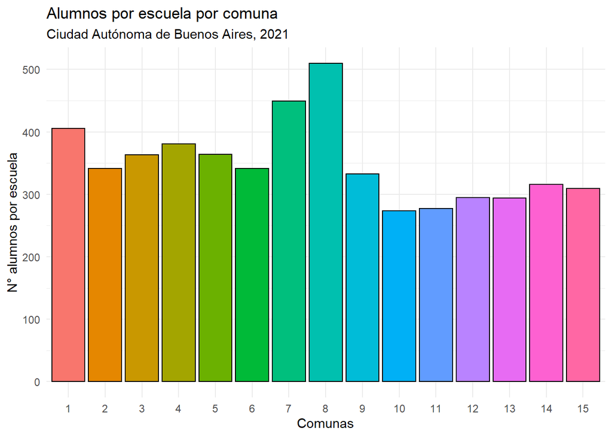

```r
Fig_1 <- ggplot(escuelas_comuna, aes(x=as.factor(comunas),y=alumn_p_escuelas,fill=comunas_n))+
  geom_col(show.legend = F,color='black')+
  labs(title = "Alumnos por escuela por comuna",
       subtitle = "Ciudad Autónoma de Buenos Aires, 2021",
       x = "Comunas",
       y = "N° alumnos por escuela") +
    theme_minimal()
Fig_1
```

A partir de esta variable alumnos por escuela se procedió a asignarle un valor entre 1 y 5 a cada comuna utilizando los cuartiles 0.75, 0.50 y 0.25. Cuanto menor es la cantidad de estudiantes por unidad educativa, más chances tendremos de conseguir vacante entonces se asignó 5 al menor valor. En cambio, el máximo valor de estudiantes por unidad educativa se le asignó el valor de 1.

```r
# Criterio 1: Disponibilidad de escuelas
escuelas_comuna <- escuelas_comuna %>%
  mutate(alumn_p_escuelas=round(alumn_p_escuelas,1)) %>%
  arrange(alumn_p_escuelas)

# definimos los límites para la puntuación
maxesc=as.numeric(max(escuelas_comuna$alumn_p_escuelas))
q3esc=as.numeric(quantile(escuelas_comuna$alumn_p_escuelas,0.75))
q2esc=as.numeric(quantile(escuelas_comuna$alumn_p_escuelas,0.50))
q1esc=as.numeric(quantile(escuelas_comuna$alumn_p_escuelas,0.25))
minesc=min(escuelas_comuna$alumn_p_escuelas)

# Ponderamos al criterio escuelas ponderando del 1 al 5. A menor numero de chicos por escuelas más probabilidad de conseguir vacante. POr lo tanto el máximo valor 5 lo tiene la menor cantidad.
escuelas_comuna <- escuelas_comuna %>%
  mutate(alumn_esc_pond=case_when(
    alumn_p_escuelas == maxesc ~ 1, # muchos alumnos por escuela
    alumn_p_escuelas < maxesc & alumn_p_escuelas >= q3esc ~ 2,
    alumn_p_escuelas < q3esc  & alumn_p_escuelas >= q2esc ~ 3,
    alumn_p_escuelas < q2esc  & alumn_p_escuelas >= q1esc ~ 4,
    alumn_p_escuelas < q1esc  & alumn_p_escuelas >= minesc ~ 5 # menos alumnos por escuela
  ))
escuelas_pond <- escuelas_comuna %>% select(comunas,alumn_p_escuelas,alumn_esc_pond) %>%
  arrange(desc(alumn_esc_pond))

# Tabla editada
Tabla_1 <- escuelas_pond %>%
  kbl() %>%
  kable_classic()

Tabla_1
```

| comunas | alumn_p_escuelas | alumn_esc_pond |
| --- | --- | --- |
| 10 | 273.6 | 5 |
| 11 | 277.1 | 5 |
| 13 | 294.0 | 5 |
| 12 | 294.5 | 5 |
| 15 | 309.7 | 4 |
| 14 | 316.1 | 4 |
| 9 | 332.4 | 4 |
| 2 | 341.1 | 3 |
| 6 | 341.3 | 3 |
| 3 | 363.4 | 3 |
| 5 | 364.2 | 3 |
| 4 | 380.5 | 2 |
| 1 | 405.5 | 2 |
| 7 | 449.4 | 2 |
| 8 | 509.6 | 1 |

Preferimos las comunas 12, 13, 11 y 10 donde tendriamos más posibilidades de conseguir vacantes en escuelas porque hay menos alumnos por escuelas. Y en la comuna 8 es donde menos probabilidad tendriamos de tener vacante en una escuela.

# 2. Criterio espacios deportivos

Practicar deportes tanto al aire libre como en espacios cerrados es un criterio muy relevante para seleccionar el barrio ideal. Dentro de la variedad de opciones encontramos: clubes de barrio, polideportivos y espacios verdes públicos. Importamos la base de datos de clubes de barrio de CABA.

```r
# Clubes de barrio. Fuente: BA Data
clubes_de_barrio_gj <- st_read('https://cdn.buenosaires.gob.ar/datosabiertos/datasets/vicejefatura-de-gobierno/clubes/clubes.geojson')

clubes_de_barrio_p <- clubes_de_barrio_gj %>% select(-tipo_normalizado,-sede,-telefono,-e_mail,-facebook,-web,-calle,-altura)


clubes_de_barrio_p_comuna <- clubes_de_barrio_p %>%
   tidyr::separate(col = comuna,into=c("comuna_ch", "comuna_n"),sep = " ") %>%
   mutate(comuna_n=as.numeric(comuna_n)) %>%
  mutate(comuna_ch=NULL) %>%
  group_by(comuna_n) %>%
  count()

clubes_de_barrio_p_comuna$ geometry=NULL

clubes_de_barrio_p_comuna <- clubes_de_barrio_p_comuna %>%
  rename(clubesbarrio_p_comuna= n ) %>%
  arrange(desc(clubesbarrio_p_comuna))

clubes_de_barrio_p_comuna
```

Las comunas 9, 11 y 15 tienen alrededor de 30 clubes de barrio, en cambio las comunas con menos clubes tienen 6 en la comuna 3 y solo 2 en la comuna 2.

```r
# Polideportivos. Fuente: BA Data
Polideportivos <- read.csv("https://cdn.buenosaires.gob.ar/datosabiertos/datasets/polideportivos/polideportivos.csv",encoding = "UTF-8")


Polideportivos_p_comuna <- Polideportivos %>%
  select(-calle,-nro,-telefono,-hor_atenc,-valor_ent,-codigo_postal,-codigo_postal_argentino) %>% group_by(comuna) %>%
  count()

Polideportivos_p_comuna$ geometry=NULL

Polideportivos_p_comuna <- Polideportivos_p_comuna %>%
  rename(Polidep_comuna=n) %>%
  arrange(desc(Polidep_comuna))

Polideportivos_p_comuna
```

Las comunas 1,2,5,6 y 15 no tienen polideportivos.Las comunas 4 y 9 son las que más tienen con 3 polideportivos cada una.

```r
# Espacios verdes públicos donde se pueden practicar distintas actividades deportivas.Fuente: BA Data.
espacios_verdes_gj <- st_read('https://cdn.buenosaires.gob.ar/datosabiertos/datasets/secretaria-de-desarrollo-urbano/espacios-verdes/espacio-verde-publico.geojson')

names(espacios_verdes_gj)

espacios_verdes_p <- espacios_verdes_gj %>%
  select(-nombre,-nombre_ev,-patio_de_j,-apadrinada,-observacio,-fuente_geo,-fuente_ins,-decreto,-fecha_decr,-ordenanza_,-fecha_orde,-boletin_of,-fecha_bole,-Fech_padri,-Vig_padri,-Alc_conven,-DGEV_Padri,-Mant_2017,-TAREAS,-ESTADO,-Canil,-Posta_aero)

unique(espacios_verdes_p$clasificac)

# Filtramos los espacios verdes muy pequeños
verdes_peque <- c("PLAZOLETA","CANTERO CENTRAL", "PATIO RECREATIVO",    "JARDÍN","PASEO","BARRIO/COMPLEJO","PATIO","PATIO DE JUEGOS INCLUSIVO")

# Me quedo con espacios verdes grandes
espacios_verdes_p <- espacios_verdes_p %>%
   filter(!clasificac %in% verdes_peque)

# Hay un problema con el paseo del bajo que esta con comuna 0 y es comuna 1.
unique(espacios_verdes_p$COMUNA)
espacios_verdes_p$COMUNA[espacios_verdes_p$COMUNA==0] <- 1

# La columna geometry es un multipolygon y no me deja agrupar, la saco.
str(espacios_verdes_p)
espacios_verdes_p$ geometry=NULL

espacios_verdes_p_comunas <- espacios_verdes_p %>%
  mutate(comuna=as.factor(COMUNA)) %>%
  group_by(comuna) %>%
  summarise(espacios_verdes=n()) %>%
  arrange(desc(espacios_verdes))

espacios_verdes_p_comunas
```

La comuna 1 tiene 68 espacios verdes, seguida por la comuna 4 con 59 espacios. En cambio la comuna 3 solo tiene 9 espacios y la comuna 5 solo 4 espacios.

```r
#Unificamos todos los espacios deportivos por comuna.

espacios_verdes_p_comunas <- espacios_verdes_p_comunas %>%
  mutate(comuna=as.numeric(comuna))

  espacios_deportivos <- clubes_de_barrio_p_comuna %>%
  left_join(Polideportivos_p_comuna,by=c('comuna_n'='comuna')) %>%
 left_join(espacios_verdes_p_comunas,by=c('comuna_n'='comuna'))

# Ahora si tenemos que tan deportiva es cada comuna de la ciudad.
espacios_deportivos <- espacios_deportivos %>%
   replace(is.na(.), 0) %>%
  mutate(esp_deport = rowSums(.[2:4])) %>%
  mutate(comunas=comuna_n) %>%
  mutate(comuna_n=as.factor(comuna_n)) %>%
  arrange(desc(esp_deport))

espacios_deportivos
```

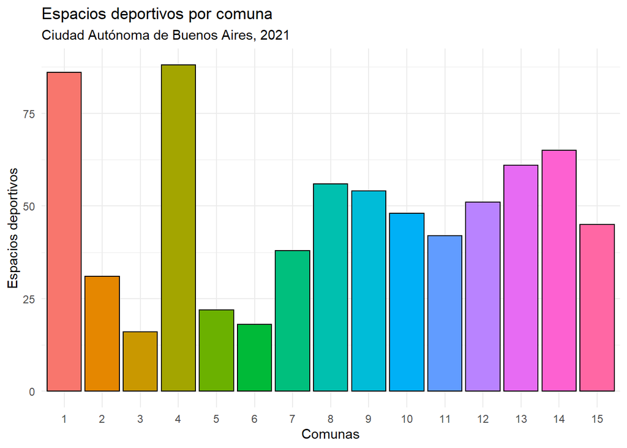

```r
Fig_2 <- ggplot(espacios_deportivos, aes(x=comuna_n,y=esp_deport,fill=comuna_n))+
  geom_col(show.legend = F,color='black')+
  labs(title = "Espacios deportivos por comuna",
       subtitle = "Ciudad Autónoma de Buenos Aires, 2021",
       x = "Comunas",
       y = "Espacios deportivos") +
    theme_minimal()
Fig_2
```

Las comunas 4 y 1 son las que más espacios deportivos tienen y las comunas 6 y 3 las que menos tienen.

Con los datos anteriores definimos la variable espacios deportivos con la cual calificamos a las comunas entre 1 y 5 usando los cuartiles anteriormente mencionados (punto 1). De tal forma las comuna con más espacios deportivos obtendrán los valores más altos (5 y 4).

```r
# Criterio 2: espacios deportivos

# definimos los limites para la puntuación
maxdep=as.numeric(max(espacios_deportivos$esp_deport))
q3dep=as.numeric(quantile(espacios_deportivos$esp_deport,0.75))
q2dep=as.numeric(quantile(espacios_deportivos$esp_deport,0.50))
q1dep=as.numeric(quantile(espacios_deportivos$esp_deport,0.25))
mindep=as.numeric(min(espacios_deportivos$esp_deport))

# # Ponderamos al criterio espacios deportivos del 1 al 5. A mayor número de espacios deportivos tiene el máximo valor (5) en la ponderación.
espacios_deportivos <- espacios_deportivos %>%
  mutate(esp_deport_pond=case_when(
    esp_deport == maxdep ~ 5,
    esp_deport < maxdep &  esp_deport >= q3dep ~ 4,
    esp_deport <  q3dep &  esp_deport >= q2dep ~ 3,
    esp_deport <  q2dep &  esp_deport >= q1dep ~ 2,
    esp_deport <  q1dep &  esp_deport >= mindep ~ 1
  ))

espacios_deportivos_pond <- espacios_deportivos %>%
  mutate(comunas=as.numeric(comuna_n)) %>%
  select(comunas,esp_deport,esp_deport_pond)


#library(DT)
#library(kableExtra)
Tabla_2 <- espacios_deportivos_pond %>%
  kbl() %>%
  kable_classic()

Tabla_2
```

| comunas | esp_deport | esp_deport_pond |
| --- | --- | --- |
| 4 | 88 | 5 |
| 1 | 86 | 4 |
| 14 | 65 | 4 |
| 13 | 61 | 4 |
| 8 | 56 | 3 |
| 9 | 54 | 3 |
| 12 | 51 | 3 |
| 10 | 48 | 3 |
| 15 | 45 | 2 |
| 11 | 42 | 2 |
| 7 | 38 | 2 |
| 2 | 31 | 1 |
| 5 | 22 | 1 |
| 6 | 18 | 1 |
| 3 | 16 | 1 |

Las comunas con más espacios para practicar deportes son la 4 y la 1, y las que menos espacios tienen son las comunas 6 y 3.

# 3. Criterio precios de alquileres

El costo de los alquileres es también un dato de suma importancia para elegir el barrio ideal. Los datos usados aportan información sobre los precios de los alquileres de los distintos barrios de 2013 a 2019. Sin embargo, la tendencia de los barrios con el mayor y menor costo de alquiler se mantiene. Aunque los datos están desactualizados son relevantes como indicadores para establecer un promedio del costo de alquiler por comuna.

```r
alquileres <- read.csv("https://cdn.buenosaires.gob.ar/datosabiertos/datasets/acceso-vivienda-y-mercado-inmobiliario/precio-alquiler-deptos.csv",encoding = "UTF-8")

alquileres_p_comuna <- alquileres %>%
  group_by(comuna) %>%
  summarise(alquiler_prom=mean(precio_prom,na.rm=T)
 ) %>% arrange(desc(alquiler_prom))

alquileres_p_comuna <- alquileres_p_comuna %>%
mutate(comuna_f=as.factor(comuna))

alquileres_p_comuna
```

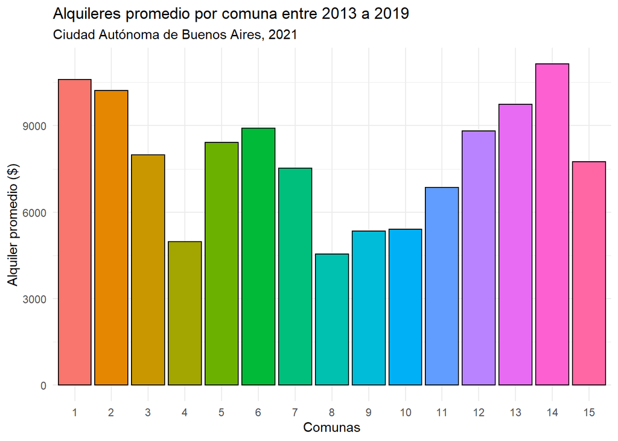

```r
Fig_3 <- ggplot(alquileres_p_comuna, aes(x=comuna_f,y=alquiler_prom,fill=comuna_f))+
  geom_col(show.legend = F,color='black')+
  labs(title = "Alquileres promedio por comuna entre 2013 a 2019",
       subtitle = "Ciudad Autónoma de Buenos Aires, 2021",
       x = "Comunas",
       y = "Alquiler promedio ($)") +
    theme_minimal()
Fig_3
```

Las comunas con los alquileres más altos son la 14, 1 y 2. Los alquileres más accesibles estan en las comunas 8, 4, 9 y 10.

Se calificó este criterio de alquileres del 1 al 5. Se prefirió los alquileres de bajo e intermedio costo y se les asignó valores de 5 y 4 , mientras que los de mayor costo tuvieron puntuaciones de 1 y 2 porque son menos preferidos.

```r
# Criterio 3: Precio promedio de alquileres
round(alquileres_p_comuna$alquiler_prom,1)

# definimos los limites para la puntuación
maxalq=as.numeric(max(alquileres_p_comuna$alquiler_prom))
q3alq=as.numeric(quantile(alquileres_p_comuna$alquiler_prom,0.75))
q2alq=as.numeric(quantile(alquileres_p_comuna$alquiler_prom,0.50))
q1alq=as.numeric(quantile(alquileres_p_comuna$alquiler_prom,0.25))
minalq=as.numeric(min(alquileres_p_comuna$alquiler_prom))

# Aca este criterio será ponderado diferente, porque los alquileres bajos e intermedios son preferibles a los alquileres altos.
alquileres_p_comuna <- alquileres_p_comuna %>%
   mutate(alquiler_prom_pond=case_when(
    alquiler_prom == maxalq ~ 1, # alquiler máximo
    alquiler_prom < maxalq &   alquiler_prom >= q3alq ~ 2, # alquileres altos
    alquiler_prom <  q3alq &   alquiler_prom >= q2alq ~ 3, # alquileres intermedios-altos
    alquiler_prom <  q2alq &   alquiler_prom >= q1alq ~ 5, # alquileres intermedios-bajos
    alquiler_prom <  q1alq &   alquiler_prom >= minalq ~ 4))# Alquileres bajos

alquileres_p_comuna <- alquileres_p_comuna %>%
  mutate(comunas=as.numeric(comuna))
alquileres_p_comuna
```

La comuna con los alquileres más caros es la 14, seguida por las comunas 1, 2 y 13. En cambio, las comunas con alquileres accesibles son las comunas 15, 7, 10, 9, 4 y 8.

# 4. Criterio familiar

Se añadió el criterio familiar que considera en cada comuna la población dentro del rango de edad de 5 y 19 años, lo cual seria un indicador de presencia de familias con niños y adolecesntes. En este caso, se prefirió las comunas en donde viven familias con hijos.

```r
# Criterio 4: familiar (presencia de niños y adolescentes)

# Estos datos los usamos en el criterio Escuelas
# chicos_edad_escolar

# definimos los límites para la puntuación
maxfam=as.numeric(max(chicos_edad_escolar$chicos_comunas))
q3fam=as.numeric(quantile(chicos_edad_escolar$chicos_comunas,0.75))
q2fam=as.numeric(quantile(chicos_edad_escolar$chicos_comunas,0.50))
q1fam=as.numeric(quantile(chicos_edad_escolar$chicos_comunas,0.25))
minfam=as.numeric(min(chicos_edad_escolar$chicos_comunas))

# Ponderamos al criterio 4
familiar <- chicos_edad_escolar %>%
  mutate(familiar_pond=case_when(
    chicos_comunas == maxfam ~ 5,
    chicos_comunas < maxfam &  chicos_comunas >= q3fam ~ 4,
    chicos_comunas <  q3fam &  chicos_comunas >= q2fam ~ 3,
    chicos_comunas <  q2fam &  chicos_comunas >= q1fam ~ 2,
    chicos_comunas <  q1fam &  chicos_comunas >= minfam ~ 1
  ))

familiar_pond <- familiar %>%
  mutate(comunas=as.numeric(comunas_n)) %>%
  mutate(comunas_n=as.factor(comunas_n))


Tabla_3 <- familiar_pond %>%
  kbl() %>%
  kable_classic()

Tabla_3
```

| comunas_n | chicos_comunas | familiar_pond | comunas |
| --- | --- | --- | --- |
| 8 | 64718 | 5 | 8 |
| 4 | 58600 | 4 | 4 |
| 7 | 52134 | 4 | 7 |
| 1 | 46632 | 4 | 1 |
| 12 | 38577 | 3 | 12 |
| 13 | 38221 | 3 | 13 |
| 9 | 37562 | 3 | 9 |
| 11 | 36294 | 3 | 11 |
| 14 | 34769 | 2 | 14 |
| 3 | 34521 | 2 | 3 |
| 15 | 34067 | 2 | 15 |
| 10 | 33656 | 1 | 10 |
| 5 | 32411 | 1 | 5 |
| 6 | 30376 | 1 | 6 |
| 2 | 21831 | 1 | 2 |

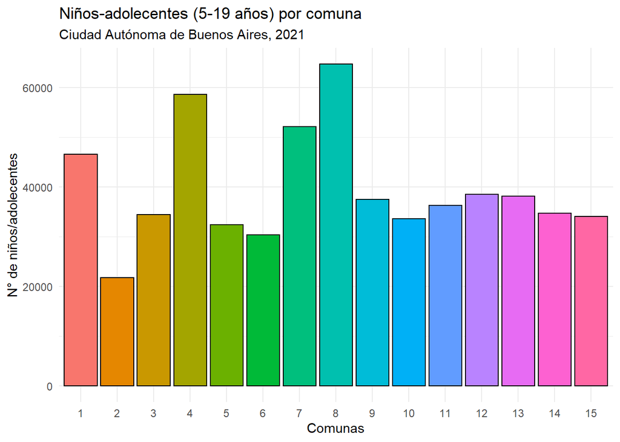

```r
Fig_4 <- ggplot(familiar, aes(x=as.factor(comunas_n),y=chicos_comunas,fill=as.factor(comunas_n)))+
  geom_col(show.legend = F,color='black')+
  labs(title = "Niños-adolecentes (5-19 años) por comuna",
       subtitle = "Ciudad Autónoma de Buenos Aires, 2021",
       x = "Comunas",
       y = "N° de niños/adolecentes") +
    theme_minimal()
Fig_4
```

Las comunas en donde viven más familias con hijos son las comunas 8, 4, 7 y 1, en cambio las comunas con menor poblacion de niños o adolescentes son las comunas 2, 6, 5 y 10.

# 5. Criterio Centros de salud

Para seleccionar el barrio ideal consideramos necesario contar con cercanía a centros de salud para acudir en caso de prevenir o atender enfermedades, tales como hospitales, centros de salud (CESAC), estaciones saludables, centros de salud privados. La cantidad de estos espacios se agruparon y se sumaron por comuna, posteriormente se ponderó con base en los cuartiles y se les asignó una calificación entre 1 y 5, en donde 1 significa poca disponibilidad y 5 mayor disponibilidad de centros de salud.

```r
# Hospitales. Fuente: BA Data.
a_hosp <- read.csv("https://cdn.buenosaires.gob.ar/datosabiertos/datasets/salud/hospitales/hospitales.csv")

# Columnas de interés
a_hosp <- a_hosp %>%
  select(ID,COD_POSTAL)

# Se inserta Comuna por código postal
# (fuente: https://www.barriorecoleta.com.ar/blog/codigos-postales/)
unique(a_hosp$COD_POSTAL) # se revisan los COD únicos

a_hosp <- a_hosp %>%
  mutate(comuna = case_when(
    COD_POSTAL == "C1270AAN" ~ "4",
    COD_POSTAL == "C1425EFD" ~ "2",
    COD_POSTAL == "C1425DUY" ~ "2",
    COD_POSTAL == "C1287ABJ" ~ "4",
    COD_POSTAL == "C1264AAA" ~ "4",
    COD_POSTAL == "C1405DCD" ~ "6",
    COD_POSTAL == "C1272AAA" ~ "4",
    COD_POSTAL == "C1275AHG" ~ "4",
    COD_POSTAL == "C1169AAB" ~ "4",
    COD_POSTAL == "C1428DQG" ~ "13",
    COD_POSTAL == "C1246ABQ" ~ "4",
    COD_POSTAL == "C1416DJI" ~ "11",
    COD_POSTAL == "C1212AAA" ~ "5",
    COD_POSTAL == "C1405BWU" ~ "6",
    COD_POSTAL == "C1424BSD" ~ "6",
    COD_POSTAL == "C1232AAC" ~ "3",
    COD_POSTAL == "C1407AOM" ~ "10",
    COD_POSTAL == "C1282AEN" ~ "4",
    COD_POSTAL == "C1427DPS" ~ "15",
    COD_POSTAL == "C1425ASQ" ~ "2",
    COD_POSTAL == "C1155AHD" ~ "4",
    COD_POSTAL == "C1425AGP" ~ "14",
    COD_POSTAL == "C1405DCS" ~ "6",
    COD_POSTAL == "C1406FWY" ~ "7",
    COD_POSTAL == "C1430BKC" ~ "12",
    COD_POSTAL == "C1419HDN" ~ "11",
    COD_POSTAL == "C1407KQF" ~ "10",
    COD_POSTAL == "C1408INH" ~ "9",
    COD_POSTAL == "C1437JLR" ~ "4",
    COD_POSTAL == "C1427ARN" ~ "15",
    COD_POSTAL == "C1406ELA" ~ "7",
    COD_POSTAL == "C1439CNU" ~ "8",
    COD_POSTAL == "C1245AAM" ~ "4",
    COD_POSTAL == "C1284AGA" ~ "4",
    COD_POSTAL == "C1221ADC" ~ "3"))

# Se agrupa por comuna y se cuantifica
comu_hosp <- a_hosp %>%
  group_by(comuna) %>%
  summarise(total = n()) %>%
  rename(hosp_comuna = total)
comu_hosp
```

```r
# Centros de Salud (CESAC). Fuente: BA Data.
a_centsal <- read.csv("https://cdn.buenosaires.gob.ar/datosabiertos/datasets/salud/centros-salud-accion-comunitaria-cesac/centros_de_salud_nivel_1_BADATA_WGS84.csv")

# Columnas de interés
colnames(a_centsal)
a_centsal <- a_centsal %>%
  select(id,comuna)

# Se agrupa por comuna y se cuantifica
comu_cesac <- a_centsal %>%
  group_by(comuna) %>%
  summarise(total = n()) %>%
  rename(cesac_comuna = total)
comu_cesac
```

```r
# Estaciones saludables. Fuente: BA Data.
a_salu <- read.csv("https://cdn.buenosaires.gob.ar/datosabiertos/datasets/vicejefatura-de-gobierno/estaciones-saludables/estaciones-saludables.csv")

# Columnas de interés
colnames(a_salu)
a_salu <- a_salu %>%
  select(id,comuna)

# Se agrupa por comuna y se cuantifica
comu_salu <- a_salu %>%
  group_by(comuna) %>%
  summarise(total = n()) %>%
  rename(saludable_comuna = total)
comu_salu
```

```r
# Centros de Salud Privados. Fuente: BA Data.
a_salpri <- read.csv("https://cdn.buenosaires.gob.ar/datosabiertos/datasets/centros-de-salud-privados/centros-de-salud-privados.csv")

# Columnas de interés
colnames(a_salpri)
a_salpri <- a_salpri %>%
  select(nombre,comuna)

# Se agrupa por comuna y se cuantifica
comu_salpri <- a_salpri %>%
  group_by(comuna) %>%
  summarise(total = n()) %>%
  rename(salprivados_comuna = total)
comu_salpri

# Se borran los datas que no se usaran
rm(a_salpri)
rm(a_centsal)
rm(a_hosp)
rm(a_salu)
```

```r
# Comuna vs Salud. Fuente: BA Data.

# En los datas "Comu_salpri" y "Comu_salu" la columna de "Comuna"
# el número viene acompañado de "Comuna", se elimina para poderlos pegar
comu_salpri$comuna <- gsub("Comuna", "", as.character(comu_salpri$comuna))
comu_salu$comuna <- gsub("Comuna", "", as.character(comu_salu$comuna))

# Se revisa que la clase de los datas y obj
class(comu_cesac)
class(comu_hosp)
class(comu_salpri)
class(comu_salu)

class(comu_cesac$comuna)
class(comu_hosp$comuna)
class(comu_salpri$comuna)
class(comu_salu$comuna)

# Se transforma a enteros
comu_hosp$comuna <- as.integer(comu_hosp$comuna)
comu_salpri$comuna <- as.integer(comu_salpri$comuna)
comu_salu$comuna <- as.integer(comu_salu$comuna)

# Se agrupan los datas por comuna
espacios_salud <- comu_cesac %>%
  full_join(comu_hosp) %>%
  full_join(comu_salpri) %>%
  full_join(comu_salu)

# Comuna y Centros de Salud ----
centros_salud_comuna <- espacios_salud %>%
  replace(is.na(.), 0) %>%
  mutate(centros_salud = rowSums(.[2:5])) %>%
  arrange(desc(centros_salud)) %>%
  mutate(comuna = as.numeric(comuna))

centros_salud_comuna
```

Encontramos que las comunas con mayor número de centros de salud son la 4 con 27 y la comuna 2 con 20 centros. En cambio las comunas con menos centros de salud son la comuna 11 con 4 y la comuna 10 con 3 centros de salud.

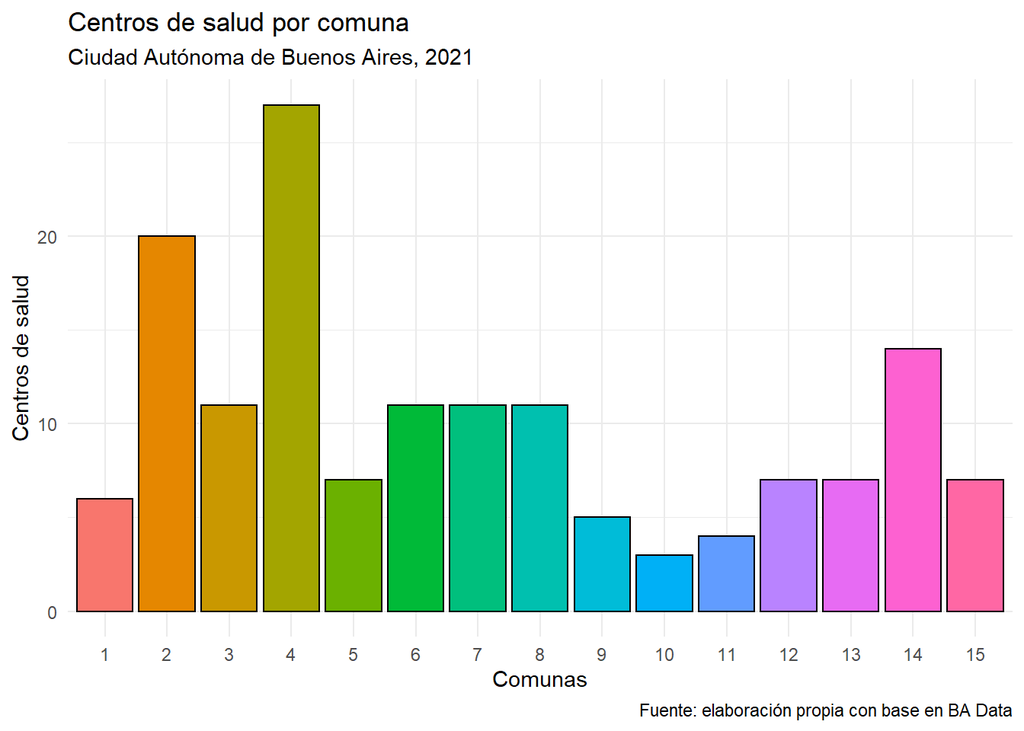

```r
# Gráfica de salud por comuna.
Fig_5 <- ggplot(centros_salud_comuna, aes(x=as.factor(comuna),y=centros_salud,fill=as.factor(comuna)))+
  geom_col(show.legend = F,color='black')+
  labs(title = "Centros de salud por comuna",
       subtitle = "Ciudad Autónoma de Buenos Aires, 2021",
       x = "Comunas",
       y = "Centros de salud",
       caption = "Fuente: elaboración propia con base en BA Data")+
  theme_minimal()

Fig_5
```

```r
# Datos geo por comuna. Fuente: BA Data.
geo_comuna <- st_read("https://cdn.buenosaires.gob.ar/datosabiertos/datasets/comunas/CABA_comunas.geojson")
geo_comuna <- clean_names(geo_comuna) # nombre de columna en minúscula

# Columas de interés
colnames(geo_comuna)
geo_comuna <- geo_comuna %>%
  select(comunas,geometry, barrios) %>%
  mutate(comuna = as.numeric(comunas))
  ############rename(comuna = comunas)

# Se unen la base con datos geo
geo_cent_salud <- geo_comuna %>% left_join(centros_salud_comuna)
```

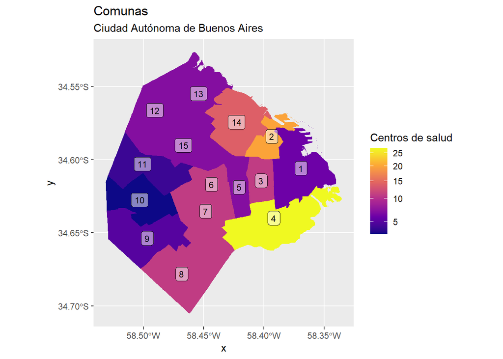

```r
# Mapa delos centros de salud por comuna----
ggplot()+
  geom_sf(data = geo_cent_salud, aes(fill = centros_salud), color = NA)+
  scale_fill_viridis_c(option = "plasma", trans = "sqrt")+
  labs(title = "Comunas",
       subtitle = "Ciudad Autónoma de Buenos Aires",
       fill = "Centros de salud")+
  geom_sf_label(data = geo_cent_salud, aes(label = comuna), size = 3, alpha = 0.5)
```

```r
# Criterio 5: centros de salud
# Ponderación----

# Límites para la puntuación
 max_hosp <- as.numeric(max(centros_salud_comuna$centros_salud))
 q3_hosp  <- as.numeric(quantile(centros_salud_comuna$centros_salud,0.75))
 q2_hosp  <- as.numeric(quantile(centros_salud_comuna$centros_salud,0.50))
 q1_hosp  <- as.numeric(quantile(centros_salud_comuna$centros_salud,0.25))
 min_hosp <- as.numeric(min(centros_salud_comuna$centros_salud))


# Ponderamos del criterio
salud_pond <- centros_salud_comuna %>%
  mutate(salud_pond = case_when(
    centros_salud == max_hosp ~ 5,
    centros_salud <  max_hosp &  centros_salud >= q3_hosp ~ 4,
    centros_salud <  q3_hosp  &  centros_salud >= q2_hosp ~ 3,
    centros_salud <  q2_hosp  &  centros_salud >= q1_hosp ~ 2,
    centros_salud <  q1_hosp  &  centros_salud >= min_hosp ~ 1))

Tabla_4 <- salud_pond %>%
  kbl() %>%
  kable_classic()

Tabla_4
```

| comuna | cesac_comuna | hosp_comuna | salprivados_comuna | saludable_comuna | centros_salud | salud_pond |
| --- | --- | --- | --- | --- | --- | --- |
| 4 | 10 | 13 | 3 | 1 | 27 | 5 |
| 2 | 0 | 3 | 17 | 0 | 20 | 4 |
| 14 | 3 | 1 | 10 | 0 | 14 | 4 |
| 3 | 2 | 2 | 7 | 0 | 11 | 4 |
| 7 | 5 | 2 | 3 | 1 | 11 | 4 |
| 8 | 10 | 1 | 0 | 0 | 11 | 4 |
| 6 | 0 | 4 | 5 | 2 | 11 | 4 |
| 5 | 1 | 1 | 5 | 0 | 7 | 3 |
| 12 | 3 | 1 | 2 | 1 | 7 | 3 |
| 15 | 1 | 2 | 4 | 0 | 7 | 3 |
| 13 | 0 | 1 | 6 | 0 | 7 | 3 |
| 1 | 4 | 0 | 2 | 0 | 6 | 1 |
| 9 | 4 | 1 | 0 | 0 | 5 | 1 |
| 11 | 1 | 2 | 1 | 0 | 4 | 1 |
| 10 | 1 | 2 | 0 | 0 | 3 | 1 |

# 6. Criterio Transporte

Mediante los datos espaciales de comunas y estaciones de subtes se realizaron intersecciones entre ambas bases de datos para obtener cuantas estaciones de subte pertenecen a cada comuna de CABA.

```r
# Estaciones de subtes. Fuente BA.
subtes <- st_read('https://cdn.buenosaires.gob.ar/datosabiertos/datasets/subte-estaciones/subte_estaciones.geojson')

# Datos espaciales de las comunas
comunas <- st_read('https://cdn.buenosaires.gob.ar/datosabiertos/datasets/comunas/CABA_comunas.geojson')

# chequeo crs para poder intersectar:
st_crs(comunas)
st_crs(subtes)

# Unimos cada estacion de subte con su respctiva comuna mediante una intersección. Obteniendo así a que comuna pertenece cada estacion.
sf::sf_use_s2(FALSE)
subtes_com = st_intersection(subtes, comunas)

subtes_cuenta = st_set_geometry(subtes_com,NULL) %>%
  select(COMUNAS) %>%
  group_by(COMUNAS) %>%
  summarise(n_estaciones_subtes = n())

names(subtes_cuenta)[1] = 'comuna_n'

rm(subtes)

subtes_cuenta
```

Hicimos lo mismo con las estaciones de bicicleta, realizamos la intersección con las comunas y calculamos cuantas estaciones de bicicleta hay en cada comuna.

```r
# Estaciones de Bicicletas. Fuente BA.
estaciones_bicicletas <- st_read('https://cdn.buenosaires.gob.ar/datosabiertos/datasets/transporte/estaciones-bicicletas-publicas/nuevas-estaciones-bicicletas-publicas.geojson')

st_crs(estaciones_bicicletas) #ok

estaciones_bicicletas = st_intersection(estaciones_bicicletas, comunas)

estaciones_bicicletas_cuenta = st_set_geometry(estaciones_bicicletas,NULL) %>%
  select(COMUNAS) %>%
  group_by(COMUNAS) %>%
  summarise(n_estaciones_bicicletas = n())

names(estaciones_bicicletas_cuenta)[1] = 'comuna_n'

rm(estaciones_bicicletas)

estaciones_bicicletas_cuenta
```

También cuantificamos el número de estaciones de ferrocarril por comuna.

```r
# Estaciones de Ferrocarril. Funete BA.

estaciones_ferrocarril <- st_read('https://cdn.buenosaires.gob.ar/datosabiertos/datasets/estaciones-de-ferrocarril/estaciones-de-ferrocarril.geojson')
st_crs(estaciones_ferrocarril) #ok

estaciones_ferrocarril = st_intersection(estaciones_ferrocarril, comunas)

estaciones_ferrocarril_cuenta = st_set_geometry(estaciones_ferrocarril,NULL) %>%
  select(COMUNAS) %>%
  group_by(COMUNAS) %>%
  summarise(n_estaciones_ferrocarril = n())


names(estaciones_ferrocarril_cuenta)[1] = 'comuna_n'

rm(estaciones_ferrocarril)

estaciones_ferrocarril_cuenta
```

Y por último, cuantificamos las estaciones de metrobus.

```r
# Estaciones de metrobus. Fuente BA.
estaciones_metrobus <- st_read('https://cdn.buenosaires.gob.ar/datosabiertos/datasets/transporte/metrobus/estaciones-de-metrobus.geojson')
st_crs(estaciones_metrobus) #ok

estaciones_metrobus = st_intersection(estaciones_metrobus, comunas)

estaciones_metrobus_cuenta = st_set_geometry(estaciones_metrobus,NULL) %>%
  select(COMUNAS) %>%
  group_by(COMUNAS) %>%
  summarise(n_estaciones_metrobus = n())


names(estaciones_metrobus_cuenta)[1] = 'comuna_n'

rm(estaciones_metrobus)

estaciones_metrobus_cuenta
```

Luego unimos todos estos datos de transporte en una variable llamada movilidad por comuna, y la ponderamos de 1 a 5. Como preferimos que haya más movilidad, tienen 5 y 4 las comunas con más movilidad.

```r
# armamos un df con todos los datos de transporte
transporte <- subtes_cuenta %>%
  full_join(estaciones_metrobus_cuenta) %>%
  full_join(estaciones_ferrocarril_cuenta) %>%
  full_join(estaciones_bicicletas_cuenta)

# Acomodamos un poquito
transporte <- transporte %>%
  mutate_all(~replace(., is.na(.), 0)) %>% # reemplazo los na con ceros
  mutate(movilidad=n_estaciones_subtes+n_estaciones_metrobus+n_estaciones_ferrocarril
         +n_estaciones_bicicletas) %>%
  arrange(desc(movilidad))

transporte
```

```r
# Criterio 6: Transporte
# definimos los limites para la puntuación
maxmov=as.numeric(max(transporte$movilidad))
q3mov=as.numeric(quantile(transporte$movilidad,0.75))
q2mov=as.numeric(quantile(transporte$movilidad,0.50))
q1mov=as.numeric(quantile(transporte$movilidad,0.25))
minmov=as.numeric(min(transporte$movilidad))

#
transporte_p_comuna <- transporte %>%
  mutate(movilidad_pond=case_when(
    movilidad == maxmov ~ 5, # transporte y bicis
    movilidad < maxmov &   movilidad >= q3mov ~ 4,
    movilidad <  q3mov &   movilidad >= q2mov ~ 3,
    movilidad <  q2mov &   movilidad >= q1mov ~ 2,
    movilidad <  q1mov &   movilidad >= minmov ~ 1))

transporte_pond <- transporte_p_comuna %>%
  mutate(comunas=as.numeric(comuna_n)) %>%
  select(-1)

Tabla_5 <- transporte_pond %>%
  kbl() %>%
  kable_classic()

Tabla_5
```

| n_estaciones_subtes | n_estaciones_metrobus | n_estaciones_ferrocarril | n_estaciones_bicicletas | movilidad | movilidad_pond | comunas |
| --- | --- | --- | --- | --- | --- | --- |
| 28 | 45 | 3 | 49 | 125 | 5 | 1 |
| 3 | 36 | 5 | 18 | 62 | 4 | 13 |
| 6 | 19 | 3 | 29 | 57 | 4 | 14 |
| 5 | 19 | 0 | 19 | 43 | 4 | 15 |
| 18 | 3 | 1 | 16 | 38 | 3 | 3 |
| 4 | 11 | 2 | 21 | 38 | 3 | 4 |
| 8 | 6 | 1 | 13 | 28 | 3 | 7 |
| 0 | 22 | 3 | 1 | 26 | 3 | 8 |
| 2 | 9 | 5 | 9 | 25 | 2 | 12 |
| 6 | 0 | 0 | 19 | 25 | 2 | 2 |
| 0 | 14 | 2 | 8 | 24 | 2 | 11 |
| 6 | 1 | 0 | 13 | 20 | 1 | 5 |
| 0 | 16 | 1 | 2 | 19 | 1 | 9 |
| 4 | 1 | 1 | 11 | 17 | 1 | 6 |
| 0 | 11 | 2 | 1 | 14 | 1 | 10 |

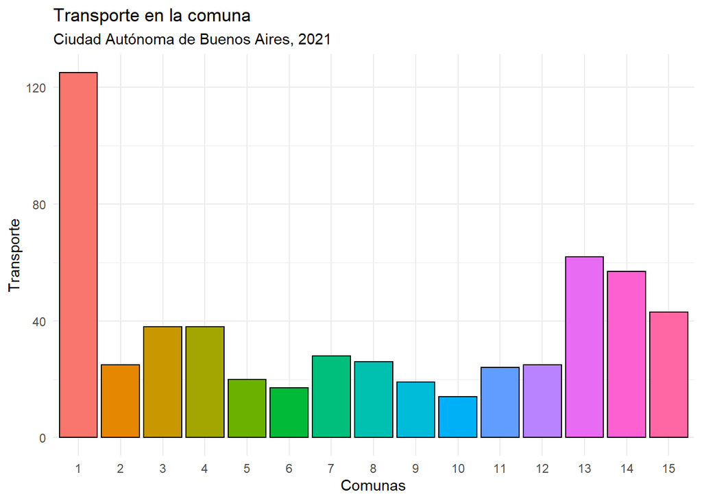

```r
# Gráfica de transporte por comuna----

Fig_6 <- ggplot(transporte_pond, aes(x=as.factor(comunas),y=movilidad,fill=as.factor(comunas)))+
  geom_col(show.legend = F,color='black')+
  labs(title = "Transporte en la comuna",
       subtitle = "Ciudad Autónoma de Buenos Aires, 2021",
       x = "Comunas",
       y = "Transporte") +
    theme_minimal()
Fig_6
```

Encontramos que la comuna 1 es la más conectada con distintos medios de transporte, seguida por la comuna 13 con un 50 %. En cambio, las comunas 6 y 10 son las menos conectadas.

# Matriz priorización

[output not shown]

Con todos los criterios categorizados, armamos la matriz de priorización.

```r
# Agregamos todos los criterios

matriz_priorizacion <- escuelas_pond %>%
   left_join(espacios_deportivos_pond, by="comunas") %>%
   left_join(alquileres_p_comuna, by="comunas") %>%
   left_join(familiar_pond, by="comunas") %>%
   left_join(salud_pond, by = "comuna") %>%
   left_join(transporte_pond, by="comunas")

matriz_priorizacion
```

```r
# Ordenamos y limpiamos
matriz_priorizacion_prolija <- matriz_priorizacion %>%
  select(-6,-8,-10,-13,-14,-15,-16,-19,-20,-21,-22)

Tabla_6 <-  matriz_priorizacion_prolija %>%
  kbl() %>%
  kable_classic()

Tabla_6
```

| comunas | alumn_p_escuelas | alumn_esc_pond | esp_deport | esp_deport_pond | alquiler_prom | alquiler_prom_pond | chicos_comunas | familiar_pond | centros_salud | salud_pond | movilidad | movilidad_pond |
| --- | --- | --- | --- | --- | --- | --- | --- | --- | --- | --- | --- | --- |
| 10 | 273.6 | 5 | 48 | 3 | 5402.381 | 4 | 33656 | 1 | 3 | 1 | 14 | 1 |
| 11 | 277.1 | 5 | 42 | 2 | 6852.289 | 5 | 36294 | 3 | 4 | 1 | 24 | 2 |
| 13 | 294.0 | 5 | 61 | 4 | 9731.333 | 2 | 38221 | 3 | 7 | 3 | 62 | 4 |
| 12 | 294.5 | 5 | 51 | 3 | 8814.776 | 3 | 38577 | 3 | 7 | 3 | 25 | 2 |
| 15 | 309.7 | 4 | 45 | 2 | 7739.920 | 5 | 34067 | 2 | 7 | 3 | 43 | 4 |
| 14 | 316.1 | 4 | 65 | 4 | 11135.568 | 1 | 34769 | 2 | 14 | 4 | 57 | 4 |
| 9 | 332.4 | 4 | 54 | 3 | 5341.500 | 4 | 37562 | 3 | 5 | 1 | 19 | 1 |
| 2 | 341.1 | 3 | 31 | 1 | 10217.842 | 2 | 21831 | 1 | 20 | 4 | 25 | 2 |
| 6 | 341.3 | 3 | 18 | 1 | 8902.586 | 3 | 30376 | 1 | 11 | 4 | 17 | 1 |
| 3 | 363.4 | 3 | 16 | 1 | 7993.196 | 3 | 34521 | 2 | 11 | 4 | 38 | 3 |
| 5 | 364.2 | 3 | 22 | 1 | 8417.216 | 3 | 32411 | 1 | 7 | 3 | 20 | 1 |
| 4 | 380.5 | 2 | 88 | 5 | 4973.696 | 4 | 58600 | 4 | 27 | 5 | 38 | 3 |
| 1 | 405.5 | 2 | 86 | 4 | 10596.204 | 2 | 46632 | 4 | 6 | 1 | 125 | 5 |
| 7 | 449.4 | 2 | 38 | 2 | 7525.939 | 5 | 52134 | 4 | 11 | 4 | 28 | 3 |
| 8 | 509.6 | 1 | 56 | 3 | 4548.300 | 4 | 64718 | 5 | 11 | 4 | 26 | 3 |

# EJEMPLO 1

```r
#con la columna del criterio ponderado. Asigno un orden a cada criterio seleccionado.
matriz_priorizacion_cr1 <- matriz_priorizacion_prolija %>%
  rename(criterio_1=familiar_pond) %>%
  rename(criterio_2=alquiler_prom_pond) %>%
  rename(criterio_3=alumn_esc_pond) %>%
  rename(criterio_4=salud_pond)

matriz_priorizacion_pesada1 <- matriz_priorizacion_cr1 %>%
      mutate(total_crit1=criterio_1*0.55) %>%
       mutate(total_crit2=criterio_2*0.30) %>%
       mutate(total_crit3=criterio_3*0.15) %>%
       mutate(total_crit4=criterio_4*0.5) %>%
       mutate(total_comuna=total_crit1+total_crit2+total_crit3+total_crit4) %>%
       mutate(COMUNAS=as.factor(comunas)) %>%
      arrange(desc(total_comuna))

matriz_priorizacion_pesada1
```

Con estas prioridades la comuna 4 sería la ideal que comprende los barrios: BARRACAS - BOCA - NUEVA POMPEYA - PARQUE PATRICIOS”

```r
# comunas
shape_comunas <- st_read("http://cdn.buenosaires.gob.ar/datosabiertos/datasets/comunas/CABA_comunas.geojson")

shape_comunas <- shape_comunas %>%
  select(COMUNAS,
          BARRIOS,
          AREA,
          geometry) %>%
   mutate(COMUNA=str_sub(COMUNAS,1,2)) %>%
  mutate(COMUNA=as.numeric(COMUNA))

shape_comunas_pesada1 <-  shape_comunas %>%
   left_join(matriz_priorizacion_pesada1, by=c('COMUNA'='comunas'))
```

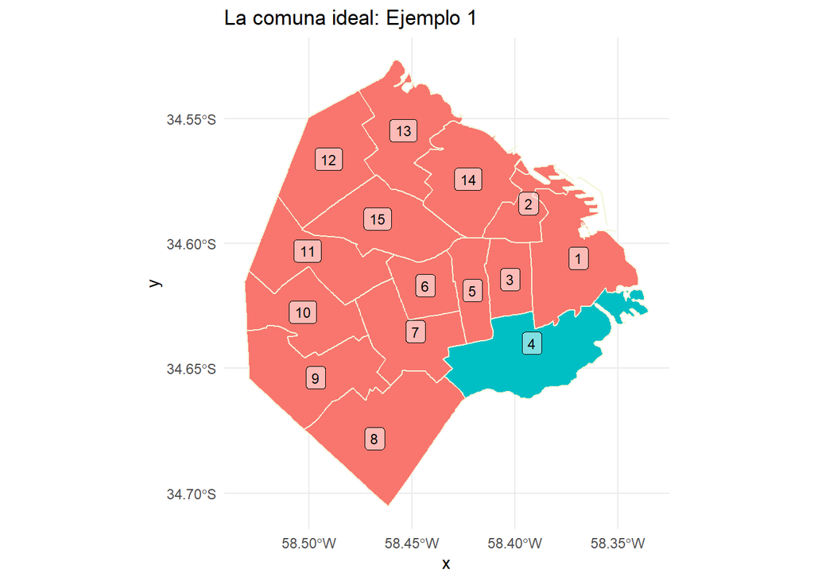

```r
# Figura/mapa
grafico_ejemplo1 <- ggplot() +
     geom_sf(data = shape_comunas_pesada1, aes(fill = total_comuna >6.15), colour = 'beige') +
     theme_minimal()+
     theme(legend.position = "none") +
     labs(title = "La comuna ideal: Ejemplo 1") +
     geom_sf_label(data = shape_comunas_pesada1, aes(label = COMUNA), size = 3, alpha = 0.5)

grafico_ejemplo1
```

# EJEMPLO 2

Lo más importante para este caso es que el barrio tenga transportes y esté bien conectado, seguido de la presencia de espacios deportivos y centros de salud cercanos, por último que el barrio sea familiar y haya chicos y adolecsentes.

```r
matriz_priorizacion_cr2 <- matriz_priorizacion_prolija %>%
  rename(criterio_1=movilidad_pond) %>%
  rename(criterio_2=esp_deport_pond) %>%
  rename(criterio_3=salud_pond) %>%
  rename(criterio_4=familiar_pond)

matriz_priorizacion_pesada2 <- matriz_priorizacion_cr2 %>%
      mutate(total_crit1=criterio_1*0.55) %>%
      mutate(total_crit2=criterio_2*0.30) %>%
      mutate(total_crit3=criterio_3*0.15) %>%
      mutate(total_crit4=criterio_4*0.5) %>%
      mutate(total_comuna=total_crit1+total_crit2+total_crit3+total_crit4) %>%
      mutate(COMUNAS=as.factor(comunas)) %>%
      arrange(desc(total_comuna))

matriz_priorizacion_pesada2
```

Segun los criterios mencionados, la comuna ideal sería la número 1 que incluye los barrios: Constitución, Montserrat, Puerto Madero, Retiro, San Nicolás y San Telmo.

```r
# comunas
shape_comunas <- st_read("http://cdn.buenosaires.gob.ar/datosabiertos/datasets/comunas/CABA_comunas.geojson")

shape_comunas <- shape_comunas %>%
  select(COMUNAS,
          BARRIOS,
          AREA,
          geometry) %>%
   mutate(COMUNA=str_sub(COMUNAS,1,2)) %>%
  mutate(COMUNA=as.numeric(COMUNA))

shape_comunas_pesada2 <-  shape_comunas %>%
   left_join(matriz_priorizacion_pesada2, by=c('COMUNA'='comunas'))
```

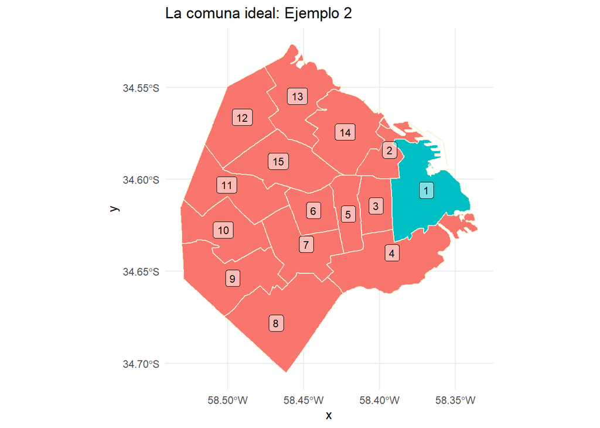

```r
# Figura/mapa
grafico_ejemplo2 <- ggplot() +
     geom_sf(data = shape_comunas_pesada2, aes(fill = total_comuna >6), colour = 'beige') +
     theme_minimal()+
     theme(legend.position = "none") +
     labs(title = "La comuna ideal: Ejemplo 2") +
     geom_sf_label(data = shape_comunas_pesada2, aes(label = COMUNA), size = 3, alpha = 0.5)

grafico_ejemplo2
```